```python
%matplotlib inline
import numpy as np
import matplotlib
import matplotlib.pyplot as plt
import scipy
from scipy import stats
import h5py

#this sets the size of the plot to something useful
plt.rcParams["figure.figsize"] = (20,15)
```

# Problem 1

```python
hf = h5py.File('gammaray_lab4.h5', 'r')
hf.keys()
data = np.array(hf.get('data'))
time = data[0,:]
sp = data[1,:]
el = data[2,:]
pc = data[3,:]
```

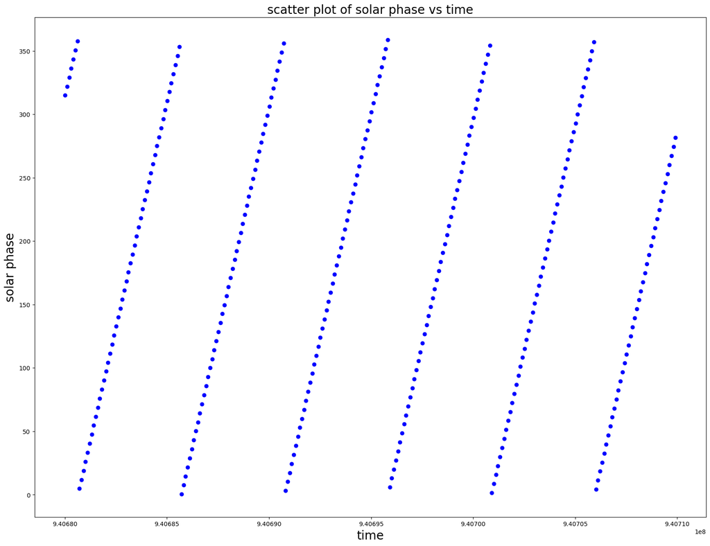

```python
start = 0
end = 300000
step = 1000

fig, ax = plt.subplots()
ax.plot(time[start:end:step], sp[start:end:step], 'o', color ='blue')
plt.title("scatter plot of solar phase vs time", fontsize = 20)
plt.xlabel("time", fontsize = 20)
plt.ylabel("solar phase", fontsize = 20)
```

[output not shown]

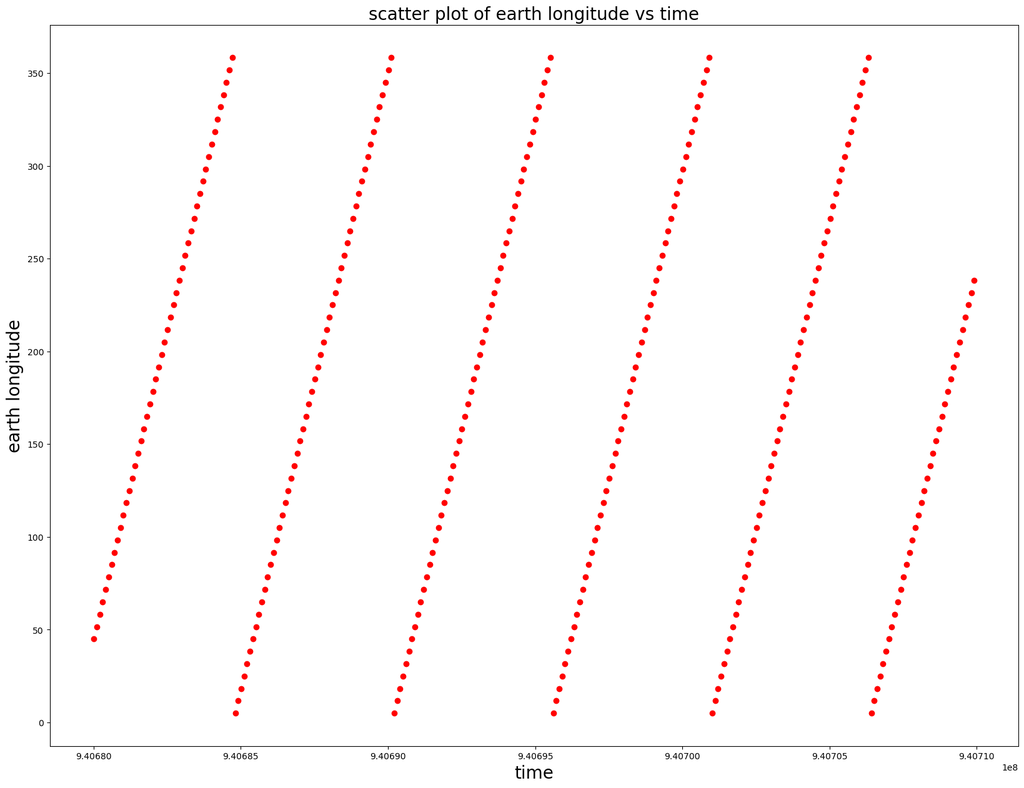

```python
fig, ax = plt.subplots()
ax.plot(time[start:end:step], el[start:end:step], 'o', color ='red')
plt.title("scatter plot of earth longitude vs time", fontsize = 20)
plt.xlabel("time", fontsize = 20)
plt.ylabel("earth longitude", fontsize = 20)
```

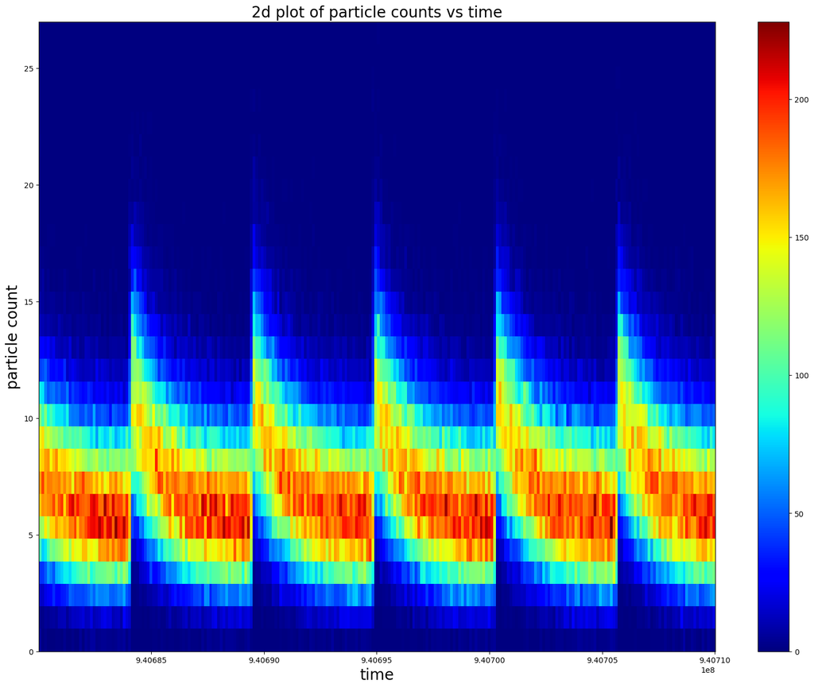

```python
plt.hist2d(time[start:end], pc[start:end],bins=(250, 28), cmap=plt.cm.jet)
plt.title("2d plot of particle counts vs time", fontsize = 20)
plt.xlabel("time", fontsize = 20)
plt.ylabel("particle count", fontsize = 20)
plt.colorbar()
plt.show()
```

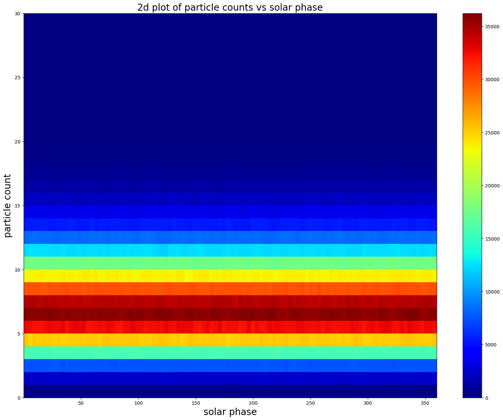

```python
size = 150
plt.hist2d(sp, pc,bins=(100, 30), cmap=plt.cm.jet)
plt.title("2d plot of particle counts vs solar phase", fontsize = 20)
plt.xlabel("solar phase", fontsize = 20)
plt.ylabel("particle count", fontsize = 20)
plt.colorbar()
plt.show()
```

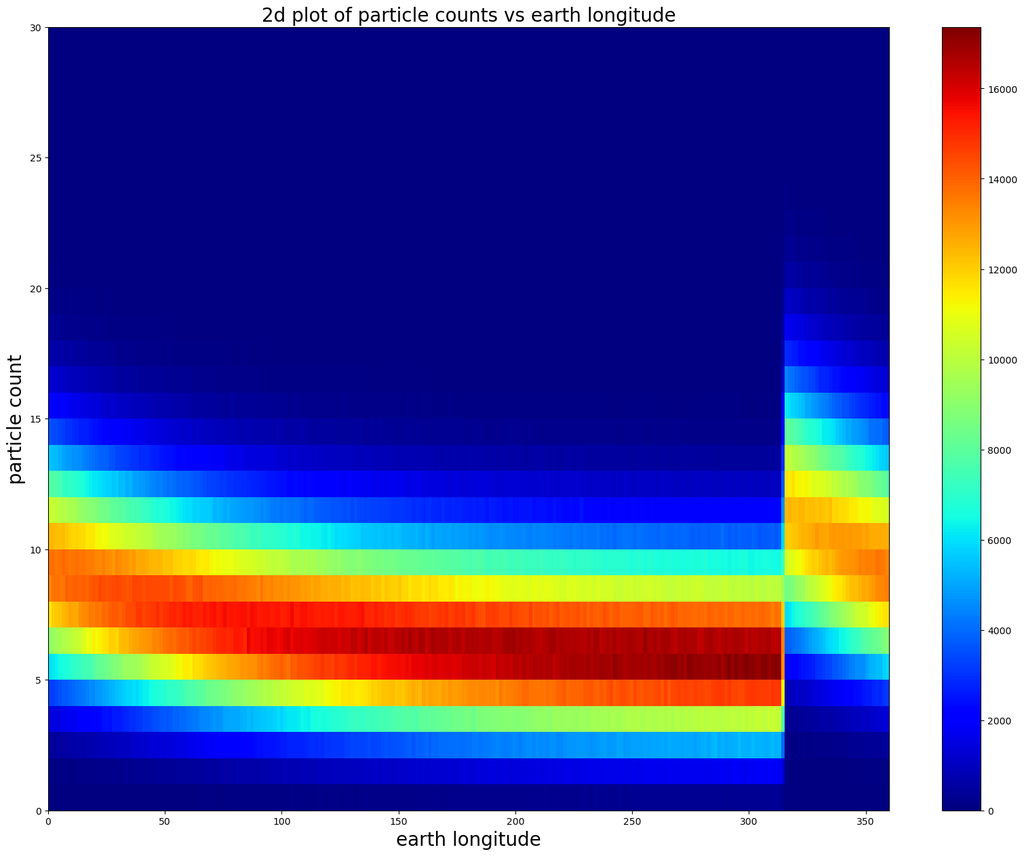

```python
size = 150
plt.hist2d(el, pc, bins=(250, 30), cmap=plt.cm.jet)
plt.title("2d plot of particle counts vs earth longitude", fontsize = 20)
plt.xlabel("earth longitude", fontsize = 20)
plt.ylabel("particle count", fontsize = 20)
plt.colorbar()
plt.show()
```

1) both the solar phase and earth longitude have a linear relationship with time, which is expected. From the 2d plot of particle count and solar phase, the probability distribution is the same regardless of the phase, which we can conclude that the solar phase is independent of particle count. However, there's a clear shift of probability distribution of particle count due to earth longitude. Given the detection of cosmic ray has, the background is expected to have Poisson pdf() with mean shift over earth longitude.

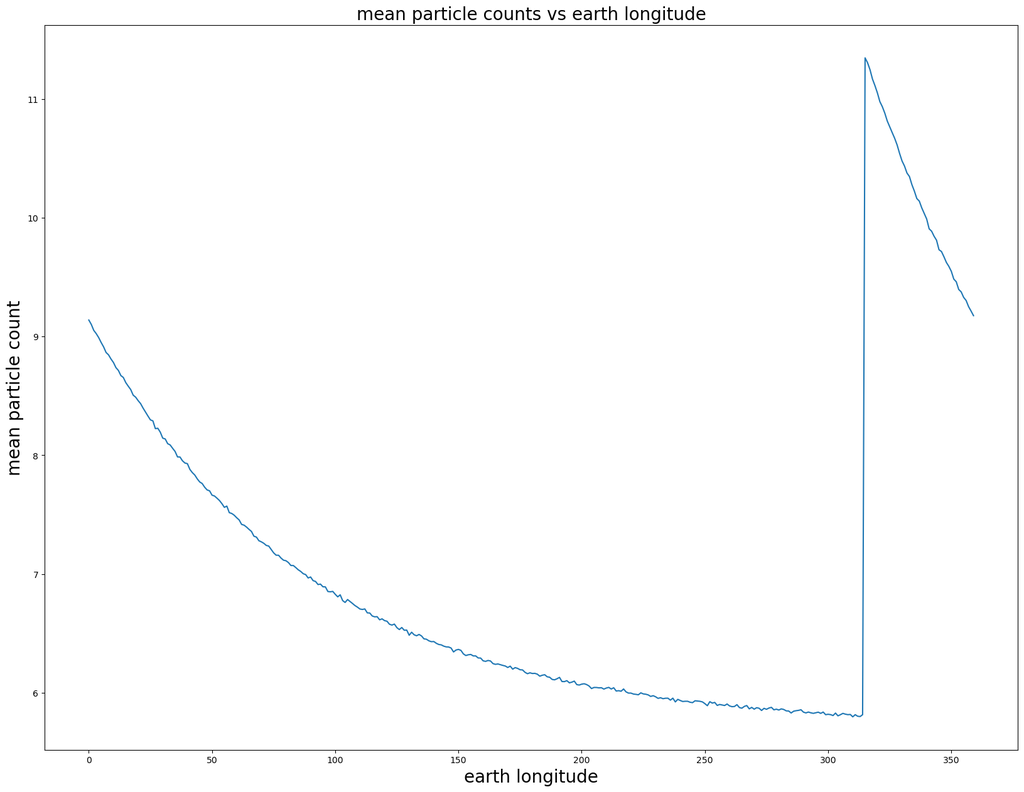

```python
fig, ax = plt.subplots()

dis = []
for x in range(0, 360):
    mask = (el > x) & (el < x+1)
    pcs = pc[mask].mean()
    dis.append(pcs)
plt.title("mean particle counts vs earth longitude", fontsize = 20)
plt.xlabel("earth longitude", fontsize = 20)
plt.ylabel("mean particle count", fontsize = 20)
ax.plot(list(range(0, 360)), dis)

# x = np.linspace(0, 360, 100)
# y = 50/((x/6)+10)+5

# plt.figure()
# ax.plot(x, y)
```

2) the above graph shows that the background is not consistent as the mean of the particle counts exponentially decreases over the earth's longitude from approx. 11.3 to 5.8 counts.

```
[10.  7.  5. ...  9.  7.  7.]
```

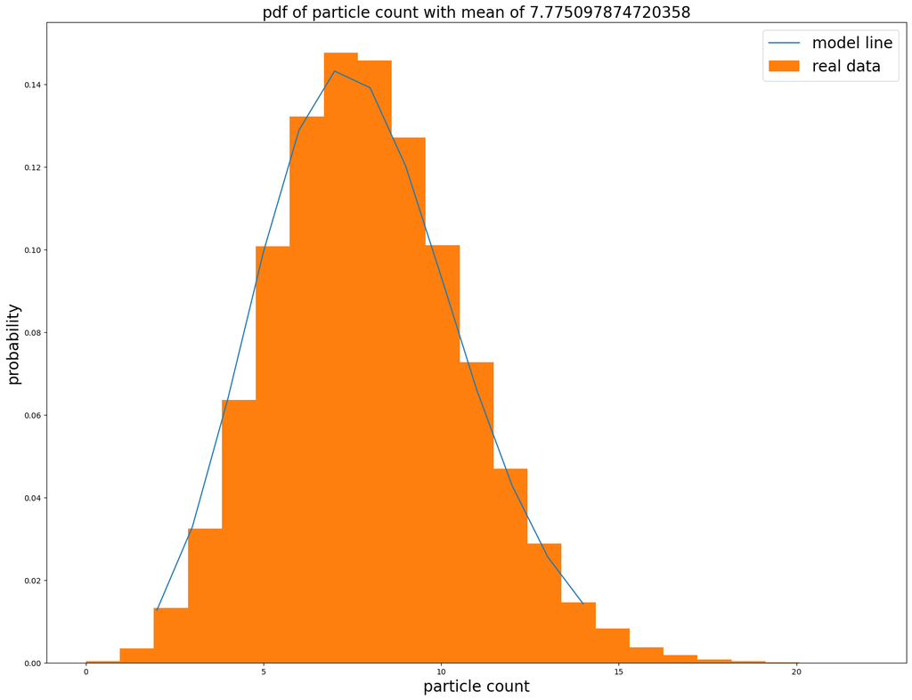

```python
# c)
from scipy.stats import poisson
fig, ax = plt.subplots()

# print(time[0])
# print(el[0])
# z= 54000
# print(time[z])
# print(el[z])
# print(time[54000]-time[0])

#for time from 940680016 in gps seconds
longitude = (45+2/30*(time[0] - 940680016))%360
mean = pc[(el > longitude) & (el < longitude+1)].mean()

d = stats.poisson(mean)

x = np.arange(poisson.ppf(0.01, mean),
              poisson.ppf(0.99, mean))
ax.plot(x,poisson.pmf(x, mean))

for x in range(0, 360):
    mask = (el > x) & (el < x+1)
    pcs = pc[mask].mean()
    if ((pcs < mean + 0.1) & (pcs> mean-0.1)):
        print(pc[mask])
        plt.hist(pc[mask], bins=23, density= True)
        break

plt.legend(["model line", "real data"], prop={'size':20})


plt.title("pdf of particle count with mean of " + str(mean)+"", fontsize = 20)
plt.xlabel("particle count", fontsize = 20)
plt.ylabel("probability", fontsize = 20)
```

3) our model fits the background pretty well with proper bin size.

```python
five_sigma = 3*10**-7

count = 28.0
print("longitude = (45+2/30*(time[index] - 940680016))%360")
for x in range(0, 360):
    mask = (el > x) & (el < x+1)
    pcs = pc[mask].mean()
    if stats.poisson.ppf(1-five_sigma, pcs) != count:
        count = stats.poisson.ppf(1-five_sigma, pcs)
        print("threshold is " + str(count) + " counts with " + str(x) +"~ earth longitude")
```

```
longitude = (45+2/30*(time[index] - 940680016))%360
threshold is 27.0 counts with 4~ earth longitude
threshold is 26.0 counts with 21~ earth longitude
threshold is 25.0 counts with 41~ earth longitude
threshold is 24.0 counts with 64~ earth longitude
threshold is 23.0 counts with 95~ earth longitude
threshold is 22.0 counts with 144~ earth longitude
threshold is 21.0 counts with 251~ earth longitude
threshold is 22.0 counts with 252~ earth longitude
threshold is 21.0 counts with 255~ earth longitude
threshold is 22.0 counts with 259~ earth longitude
threshold is 21.0 counts with 260~ earth longitude
threshold is 32.0 counts with 315~ earth longitude
threshold is 31.0 counts with 318~ earth longitude
threshold is 30.0 counts with 328~ earth longitude
threshold is 29.0 counts with 338~ earth longitude
threshold is 28.0 counts with 351~ earth longitude
```

# Problem 2

```
(200, 200, 10)
```

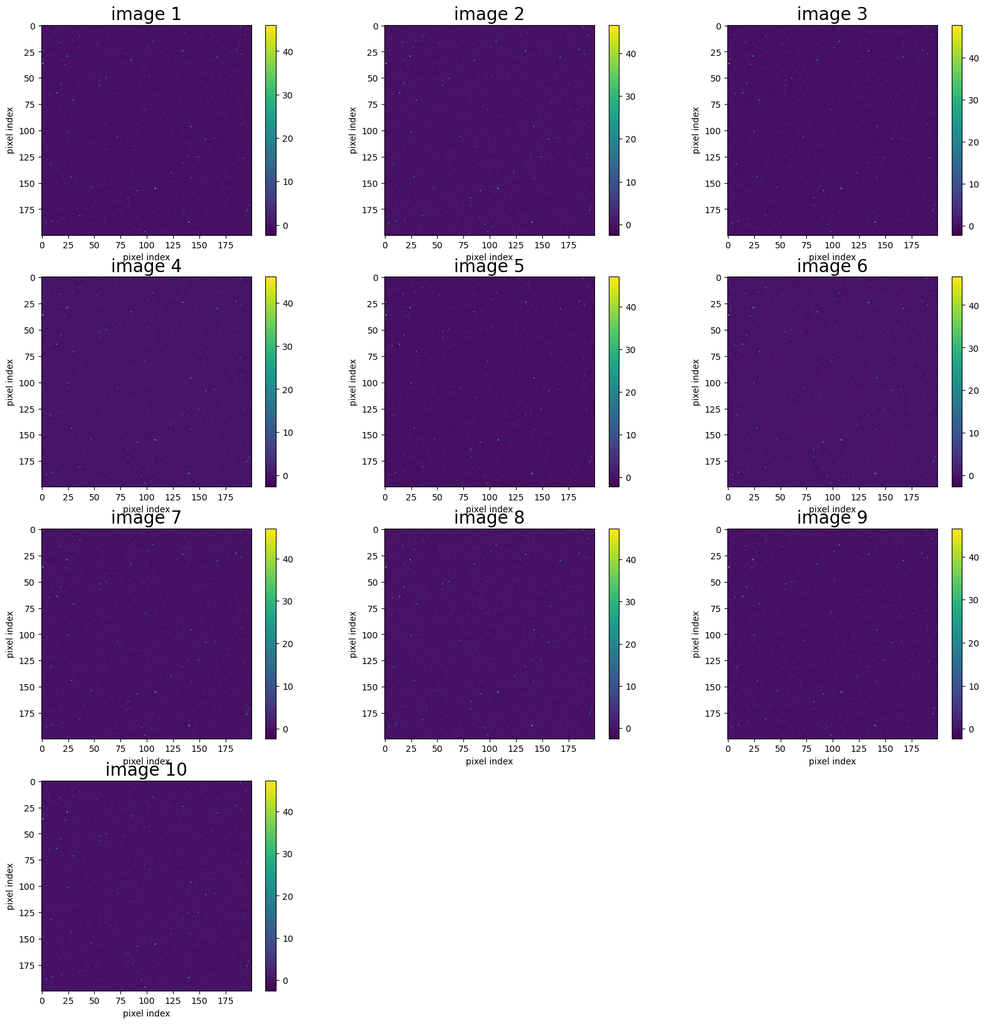

```python
hf = h5py.File('images.h5', 'r')
hf.keys()
data = np.array(hf.get('imagestack'))
print(data.shape)

fig = plt.figure(figsize=(20, 20))

rows = 4
columns = 3
for x in range(0,10):
    #plt.figure()

    fig.add_subplot(rows, columns, x+1)
    plt.title("image " + str(x+1), fontsize = 20)
    plt.xlabel("pixel index")
    plt.ylabel("pixel index")


    plt.imshow(data[:,:,x])
    plt.colorbar()
```

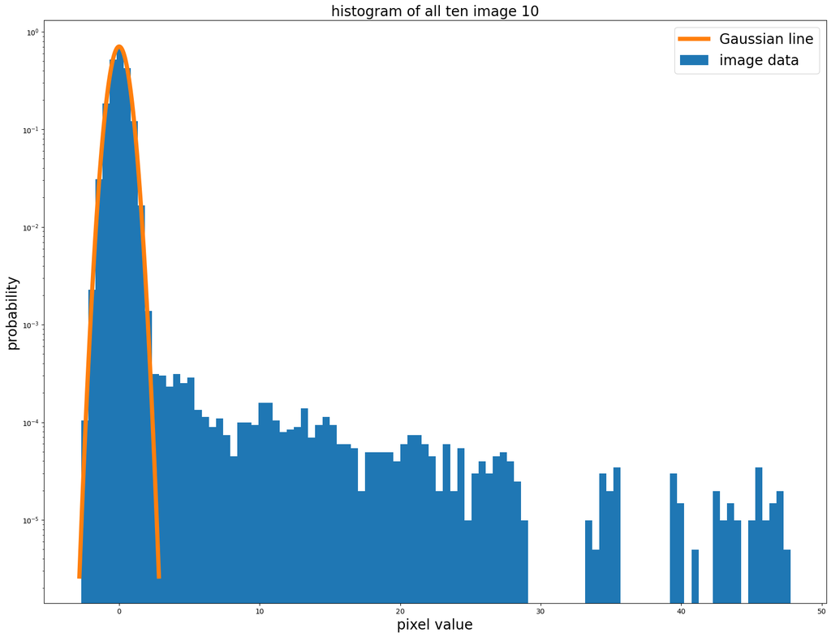

```python
mask = data < 4


plt.hist(data.ravel(), bins=100, density= True)

mean = data[mask].mean()
variance = data[mask].var()
std = data[mask].std()
sigma = math.sqrt(variance)

x_axis = np.linspace(mean - 5*sigma, mean + 5*sigma, 100)
plt.plot(x_axis, stats.norm.pdf(x_axis, mean, std), linewidth=6)

plt.legend(["Gaussian line", "image data"], prop={'size':20})
plt.yscale('log')
plt.title("histogram of all ten image " + str(x+1), fontsize = 20)
plt.xlabel("pixel value", fontsize = 20)
plt.ylabel("probability", fontsize = 20)

plt.show()
```

2) There exist signal contamination as noise and shifting signals frrom the stars stars. When looking for a transient, the background is time-dependent since transient has the attribute of rapid rise time. The data is consistent spatially.

To find a supernova, I first need to get rid of bad data such as the background noise. With good data set, I then need to look for the appearance of a star that only happens in one image, so the pixel reading of a transient should have a sudden change in one image over the ten images. This can be determined by looking for the distribution of the pixel valus, if there's a sudden rise, then the pixel reading is likely to be a transient.

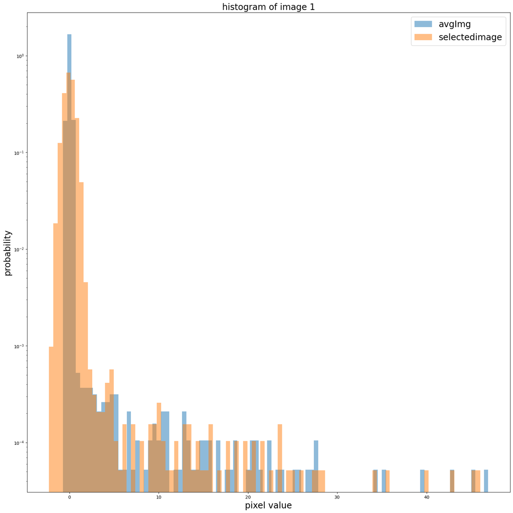

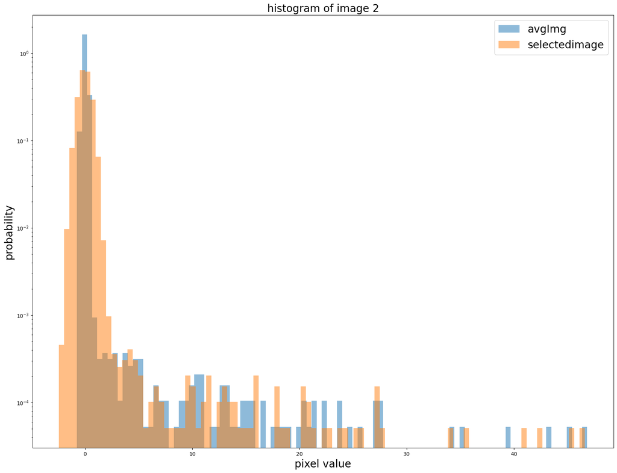

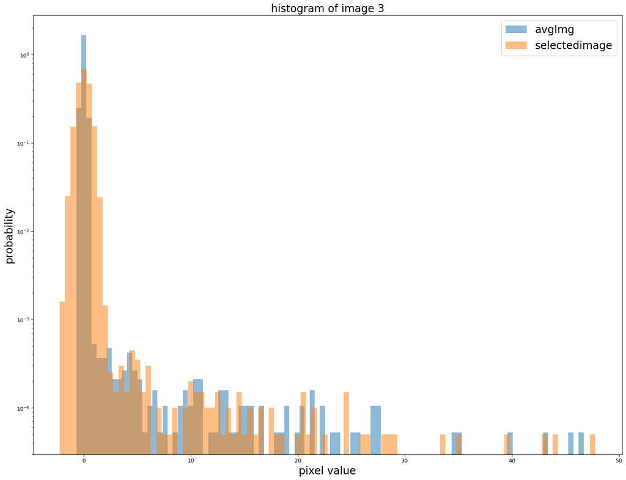

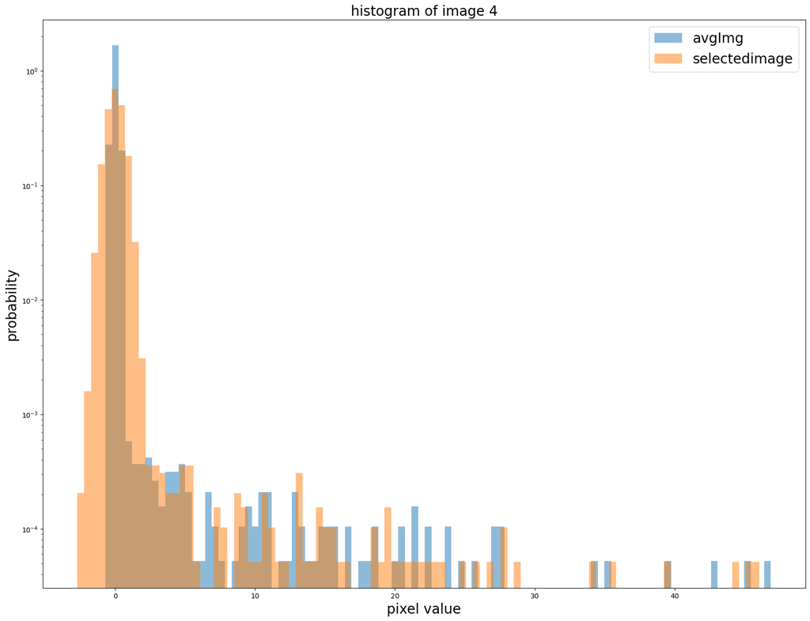

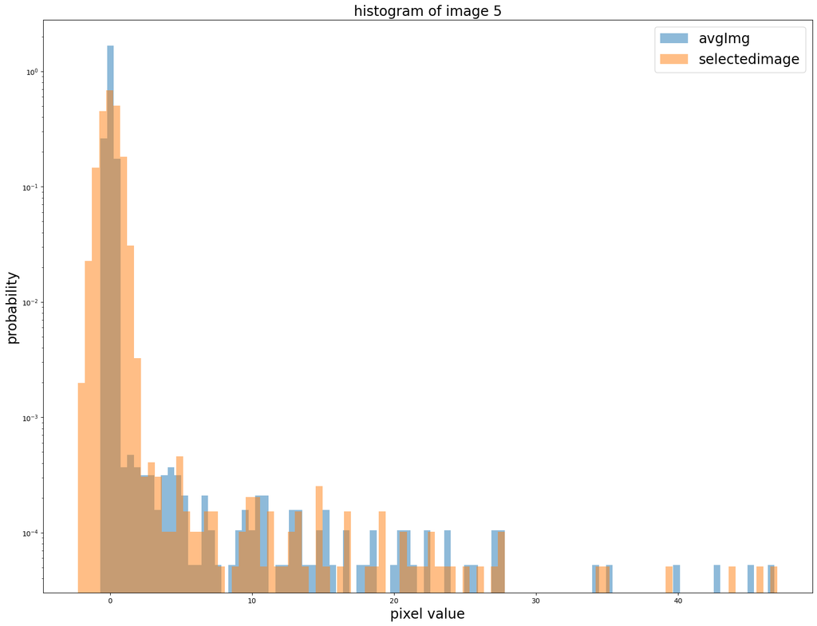

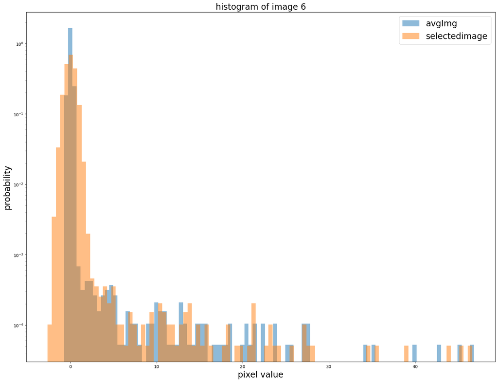

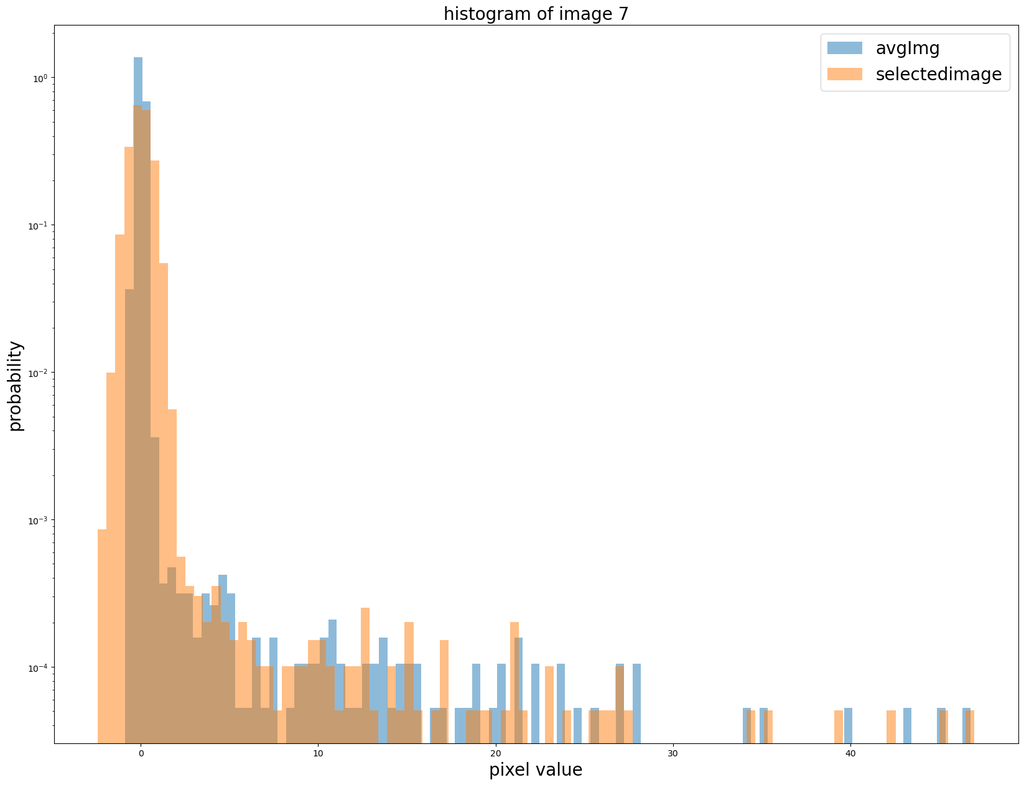

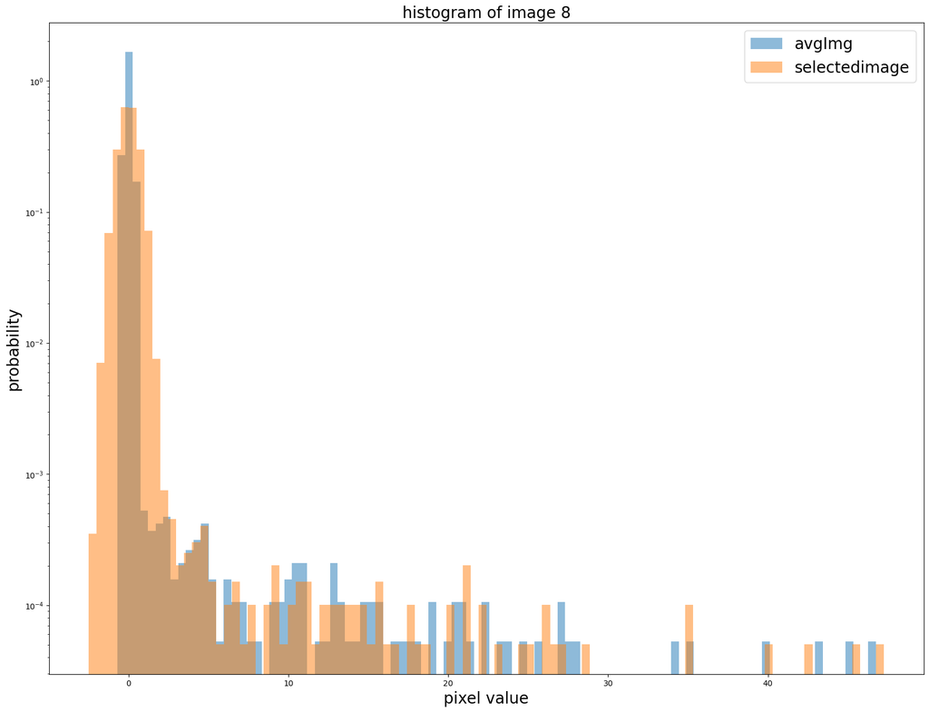

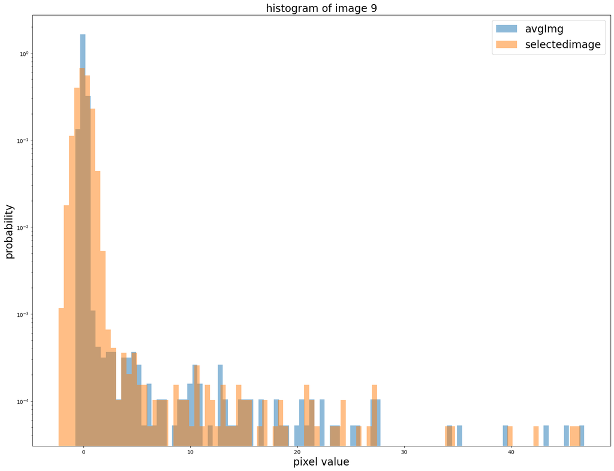

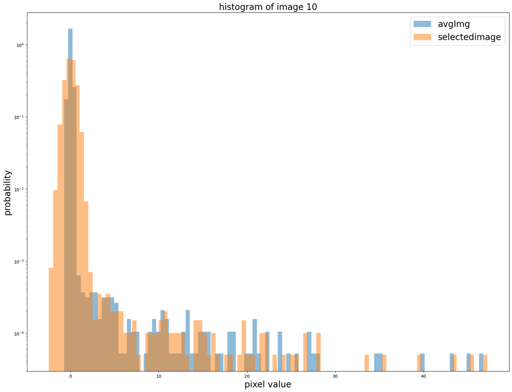

```python
import math

fig = plt.figure(figsize=(20, 20))

rows = 4
columns = 3
for x in range(0,10):
    selectedimage = data[:,:,x]
    avgImg = np.delete(data[:][:], x, axis=2).mean(2)

    size = 100
    hist1 = plt.hist(avgImg.ravel(), bins=size, density= True, alpha = 0.5)
    hist2 = plt.hist(selectedimage.ravel(), bins=size, density= True, alpha = 0.5)
#     mean = data[:,:,x].mean()
#     variance = data[:,:,x].var()
#     std = data[:,:,x].std()
#     sigma = math.sqrt(variance)

#     x_axis = np.linspace(mean - 5*sigma, mean + 5*sigma, 100)
#     plt.plot(x_axis, stats.norm.pdf(x_axis, mean, std))
    plt.legend(["avgImg", "selectedimage"], prop={'size':20})
    plt.yscale('log')

    plt.title("histogram of image " + str(x+1), fontsize = 20)
    plt.xlabel("pixel value", fontsize = 20)
    plt.ylabel("probability", fontsize = 20)
    plt.show()
```

```
10
16
8
11
23
9
14
8
18
17
```

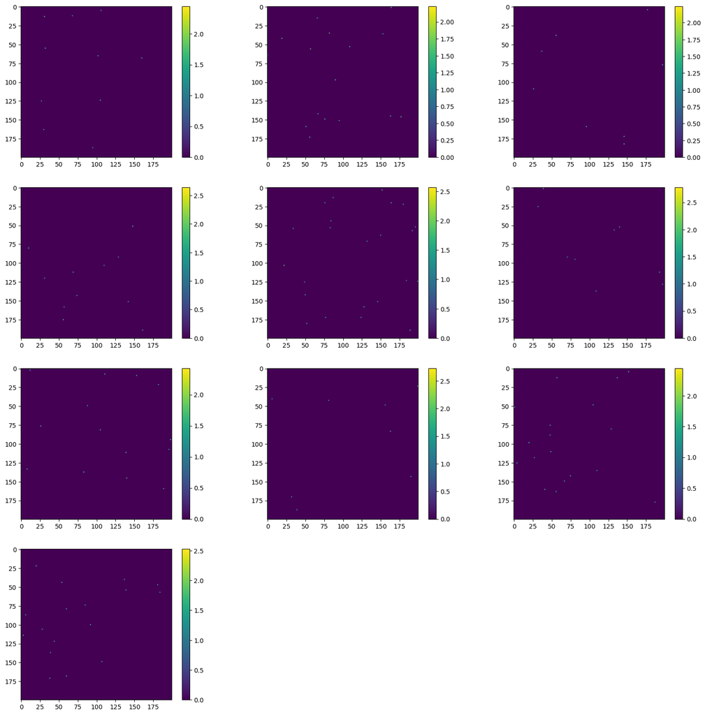

```python
fig = plt.figure(figsize=(20, 20))
rows = 4
columns = 3

pixelshiftV = 2
for x in range(0,10):
    avgImg = np.delete(data[:][:], x, axis=2).mean(axis=2)
    #avgImg = data[:,:,9]
    selImg = data[:,:,x]
    subImg = avgImg - selImg

    #print(subImg.shape)

    fig.add_subplot(rows, columns, x+1)
    mask = subImg > pixelshiftV

    plt.imshow(subImg*mask)
    plt.colorbar()
    #print(subImg)
    print(len(subImg[mask]))
```

```
0
0
0
0
0
0
0
0
0
0
```

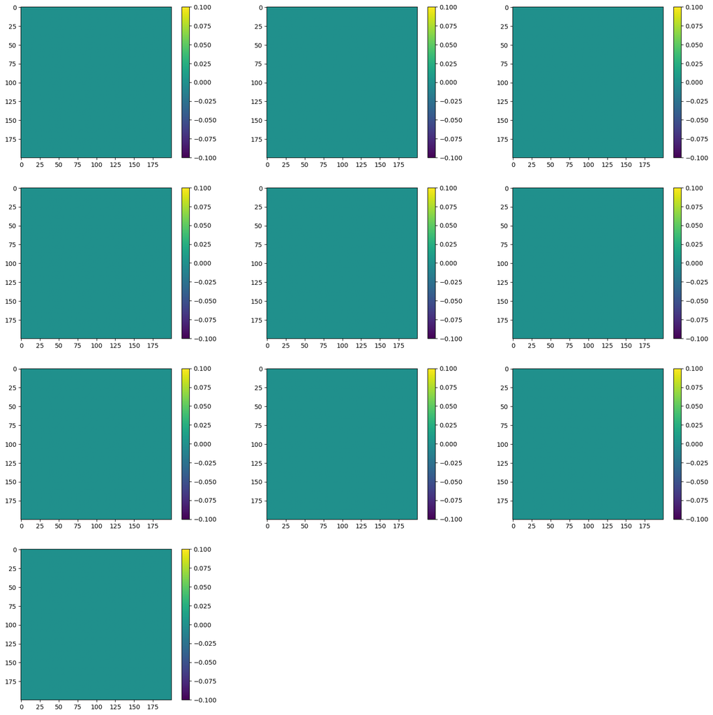

```python
fig = plt.figure(figsize=(20, 20))
rows = 4
columns = 3

pixelshiftV = 3
for x in range(0,10):
    avgImg = np.delete(data[:][:], x, axis=2).mean(axis=2)
    #avgImg = data[:,:,9]
    selImg = data[:,:,x]
    subImg = avgImg - selImg

    #print(subImg.shape)

    fig.add_subplot(rows, columns, x+1)
    mask = subImg > pixelshiftV

    plt.imshow(subImg*mask)
    plt.colorbar()
    #print(subImg)
    print(len(subImg[mask]))
```

4.Though we use the same data, the question which we address are different, which means the signal pdf that we are looking are different. For finding the transient, I need to look for the signal that appears in one image and should have a clear rise of pixel value. For looking at the dimmiest stars, since the stars are constant, there should exist a signal with low pixel value throughout all ten images. And the pdf can be found by exploring the mean of all then image and signal of the low pixel value stars.